# From the power law to extreme value mixture distributions

Clement Lee (Newcastle University)

2024-06-30

# Outline

- Networks $\times$ extreme value theory
- Extending the power law for degrees
- Mixture distribution
  - even for data simulated from “true” random graph models
  - finite sample behaviour
- Compare results for real & simulated data
  - make models more realistic?
- Studying the evolution of real data
- Slides: https://bit.ly/sunbelt2024

[figure not shown]

- R package: https://cran.r-project.org/package=crandep
- Paper: https://doi.org/10.1111/stan.12355

# 1. Introduction

# Degree distribution

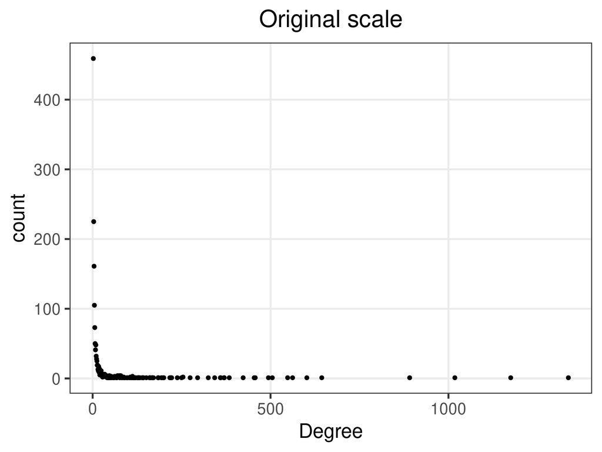

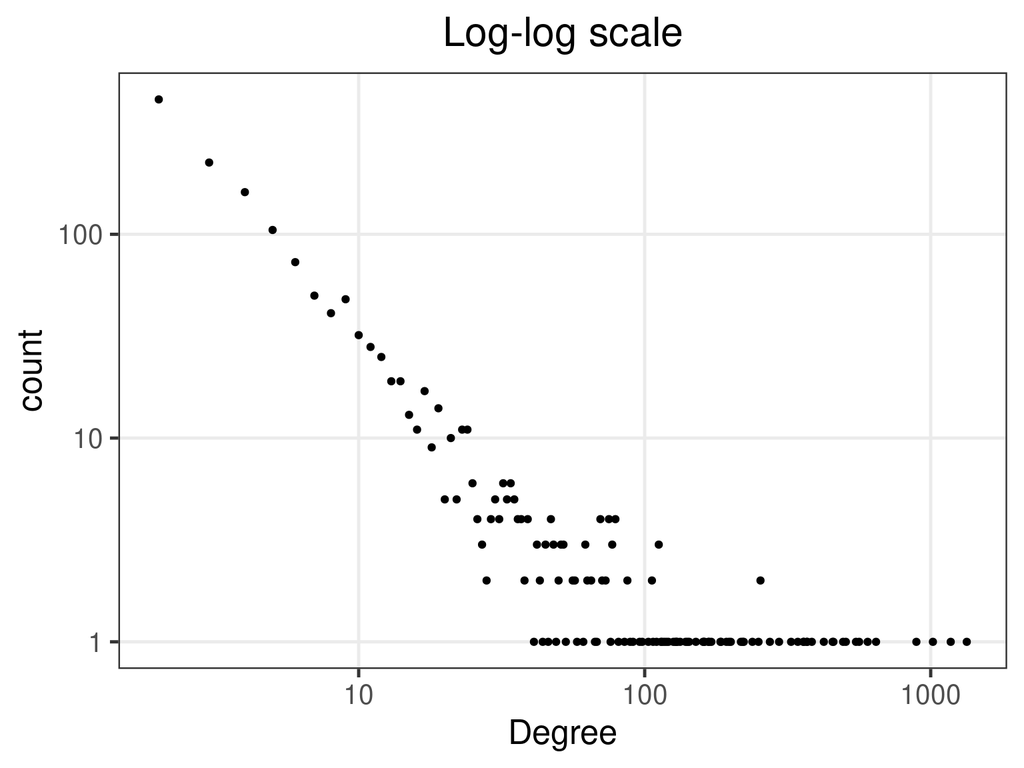

# Why the power law?

- Seemingly ubiquitous
- Potentially generated from “nice” models
  - Preferential attachment (Barabasi-Albert)
  - Generalised random graphs

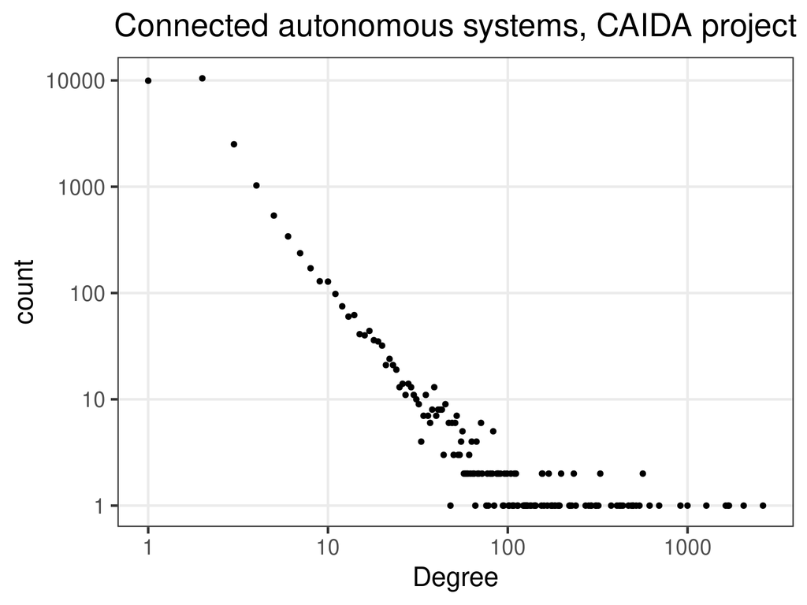

- Left: http://konect.cc/networks/as-caida20071105/
- Right: Valero, Pérez-Casany, and Duarte-López (2022)
- Both available at https://github.com/adbroido/SFAnalysis

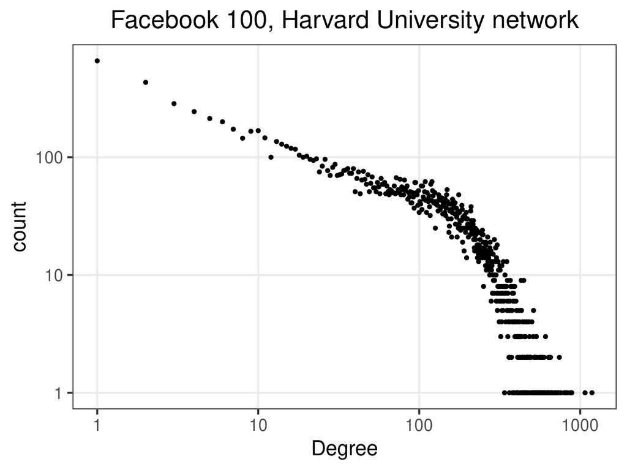

# Really a straight line?

- Survival function / complementary CDF

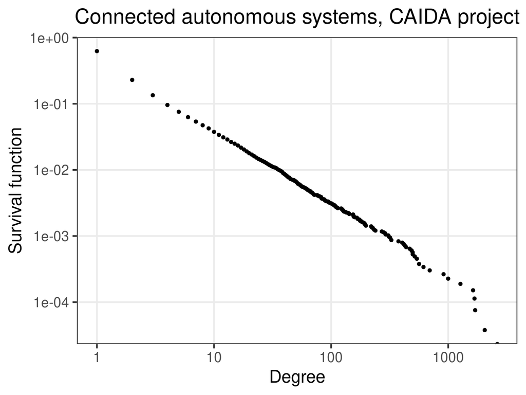

- “Curved” downwards

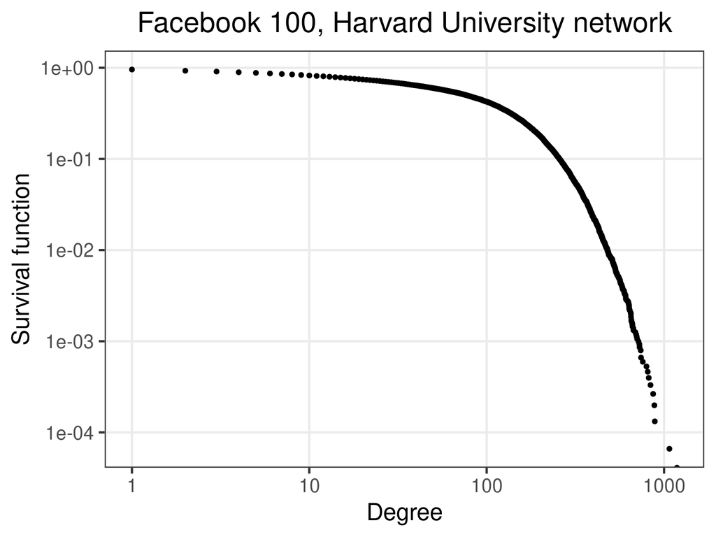

# Tackling various issues

- Small degrees deviate from straight line
  - subsets data above $u$; chooses optimal $u$ by K-S statistic (Clauset, Shalizi, and Newman 2009)
  - basis of hypothesis testing framework (Broido and Clauset 2019)
  - requires additional procedure
- Large degrees deviate from straight line
  - incorporates extreme value theory (Voitalov et al. 2019)
  - only allows “heavy” tails; not always true for real data
- “Curvature” shown by some data
  - Double power law (Ayed, Lee, and Caron 2019)
  - Zipf-polylog distribution (Valero, Pérez-Casany, and Duarte-López 2022)
  - still quite restrictive
- Related works
  - de Solla Price model (Artico et al. 2020)
  - mixture of Zipf distributions (Jung and Phoa 2021)

# 2. Extreme value mixture distribution

# Primer: relationships

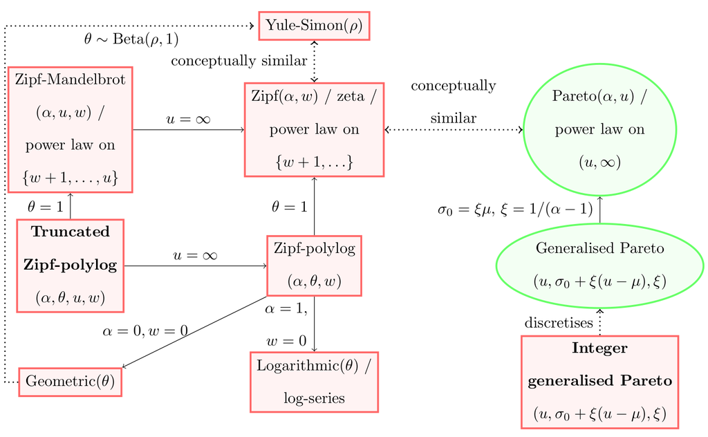

# Schematic, on log-log scale

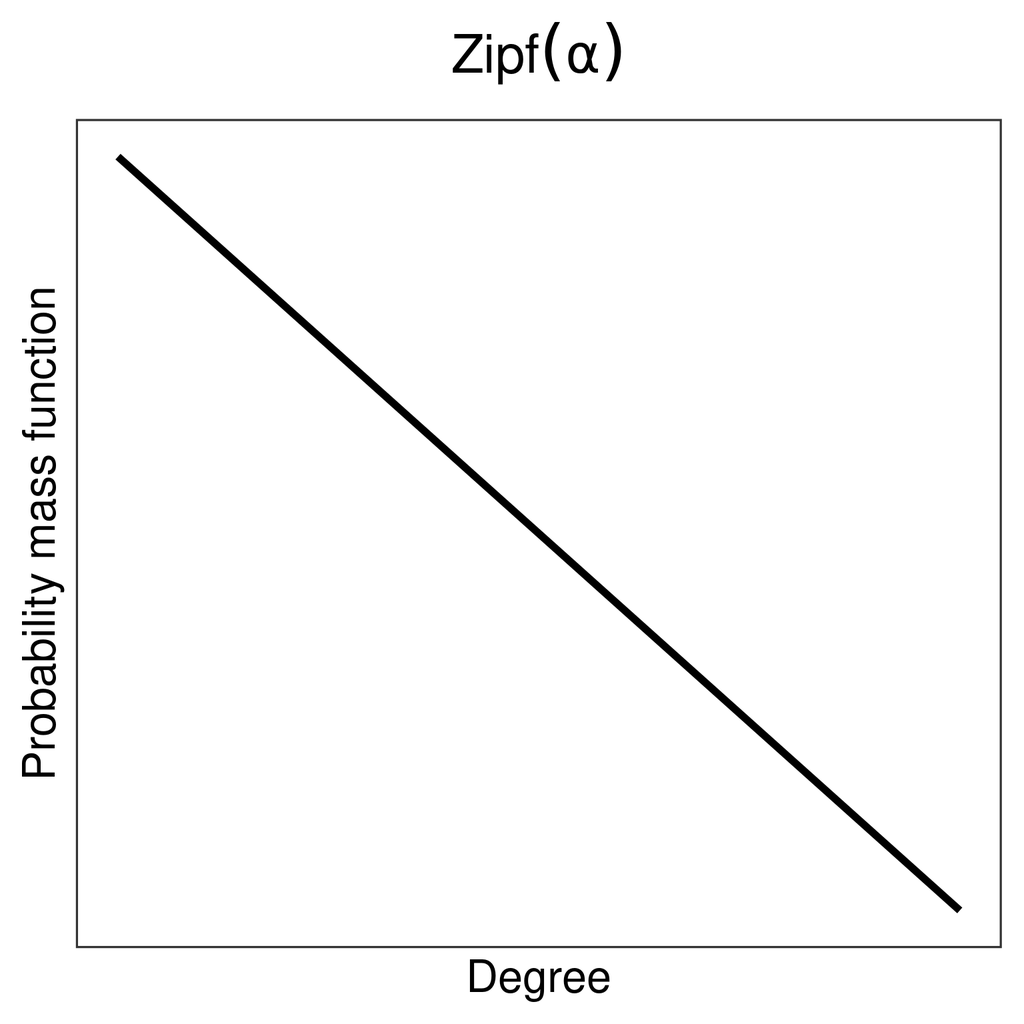

- Slope: $-\alpha(<-1)$
- Tail heaviness: $1/(\alpha-1)$

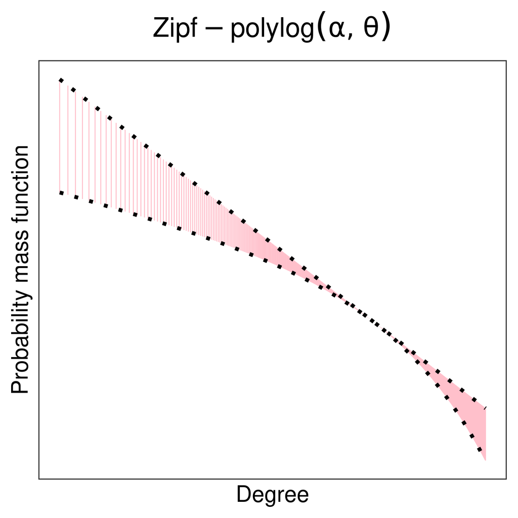

- $\theta\in(0,1]$
- Reduced to Zipf$(\alpha)$ when $\theta=1$

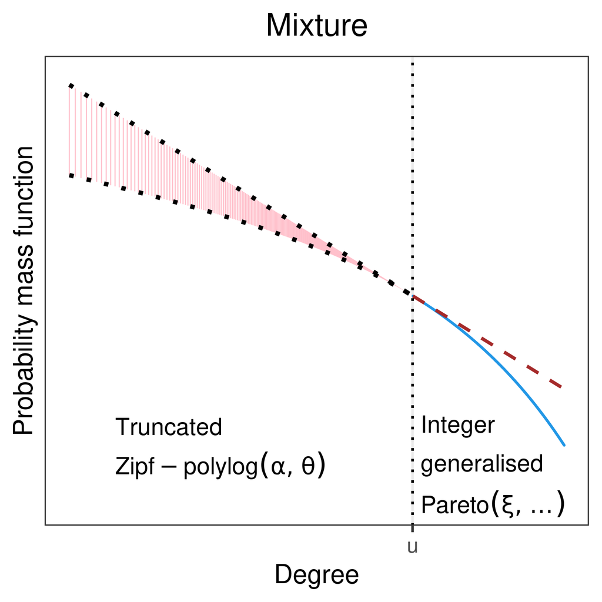

- Blue’s tail heaviness: $\xi$
- Brown’s tail heaviness: $1/(\alpha-1)$
  - **had the power law extended beyond** $u$

# Bayesian inference

- Prior $+$ data $\rightarrow$ posterior
- Uncertainty expressed naturally
- Threshold $u$ close to maximum - power law **could be** adequate
- Can even test between Zipf (straight line) and polylog (curved)
  - model selection within inference

# CRAN dependencies

- R packages available at https://cran.r-project.org/
- `imports` between packages

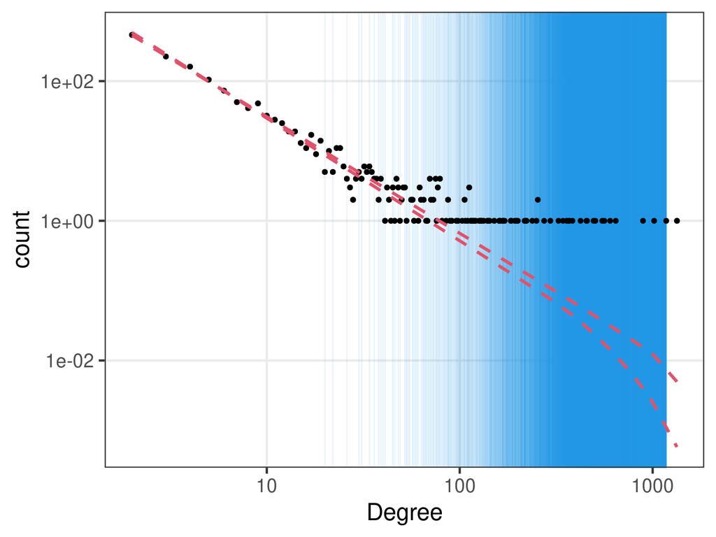

- Mixture distribution improves fit
- Better than alternatives

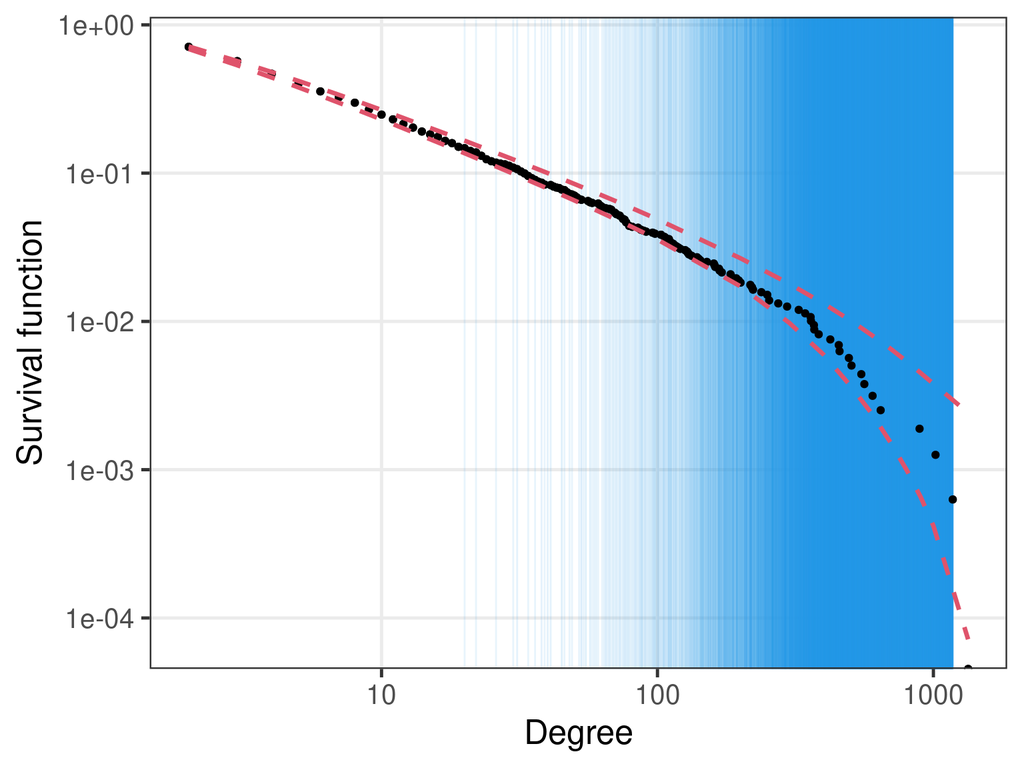

# Simulated data

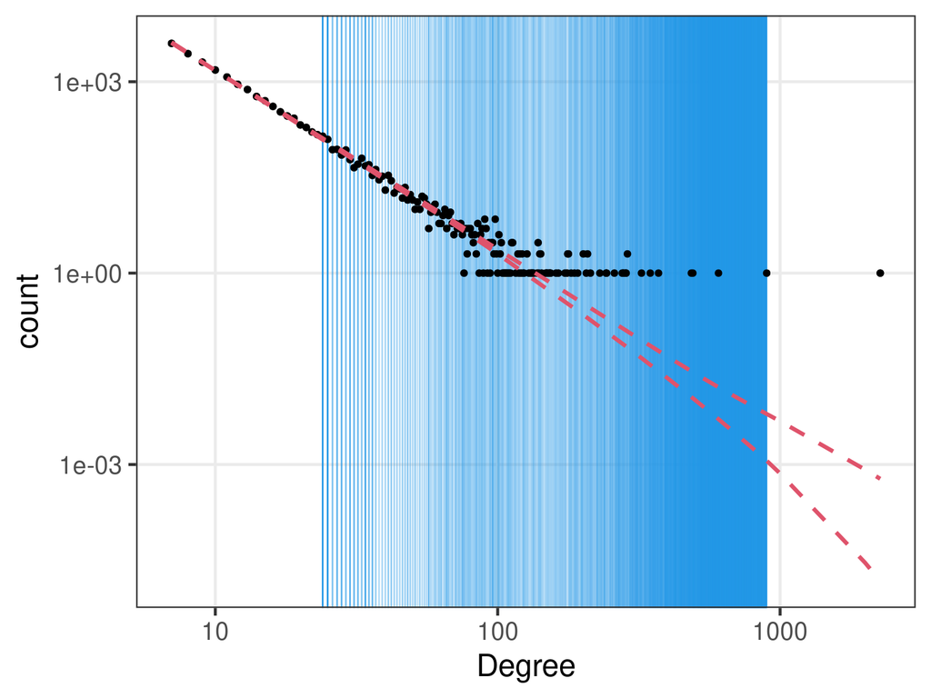

```r
library(igraph); set.seed(5772)
sample_pa(n = 500000, directed = FALSE,
          m = 1, zero.appeal = 1.0e-4)
```

- Not clear-cut even when simulated from true model
- Uncertainty & finite sample behaviour

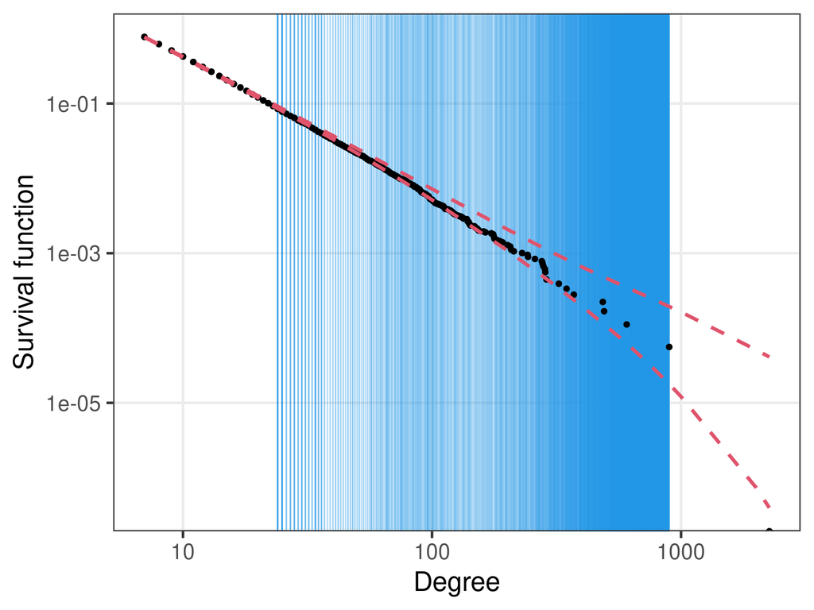

# Tail heaviness: actual vs implied

- Indication whole of data **could** follow the power law
- Huge uncertainty of $\xi$ still

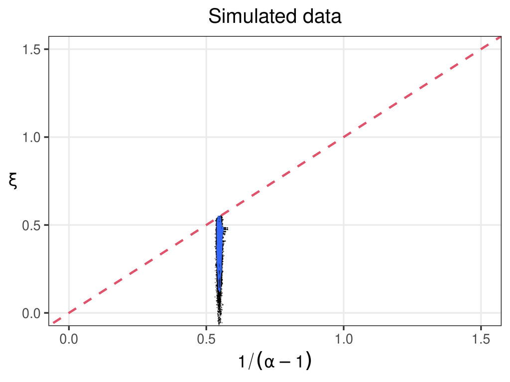

- Away from $y=x$ line
- Difficult to have **sustained** growth according to $\alpha$

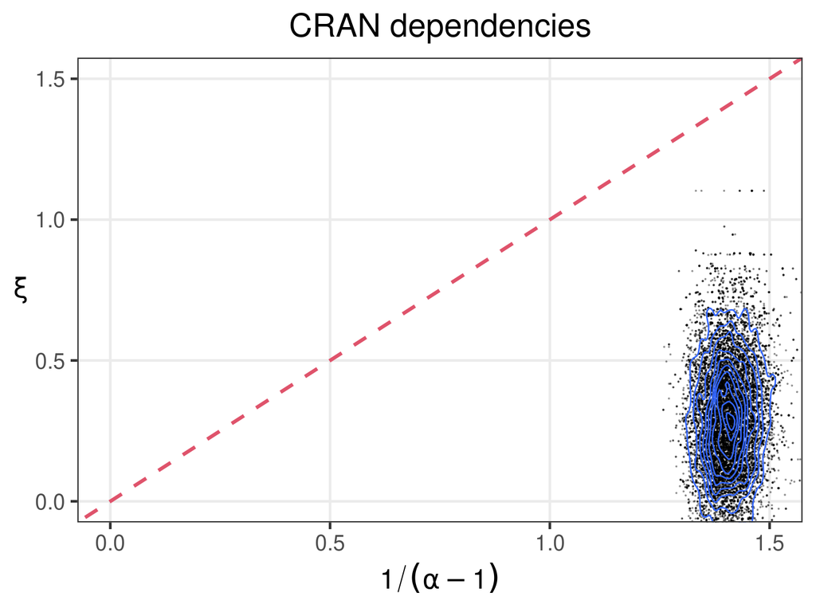

# 3. Evolution over time

# Tail heaviness relatively stable

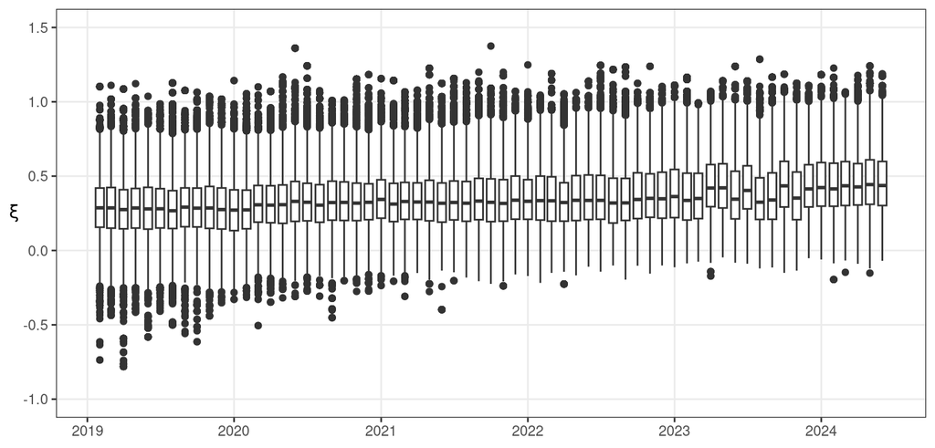

# So is the power law exponent

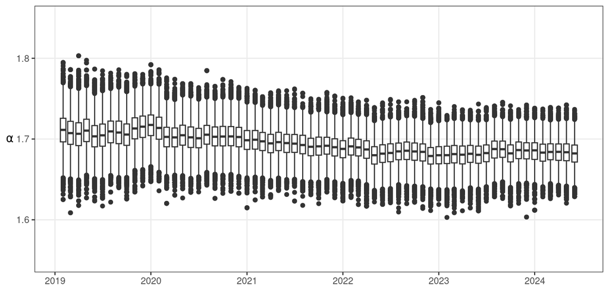

# Tail steadily lighter than implied by power law

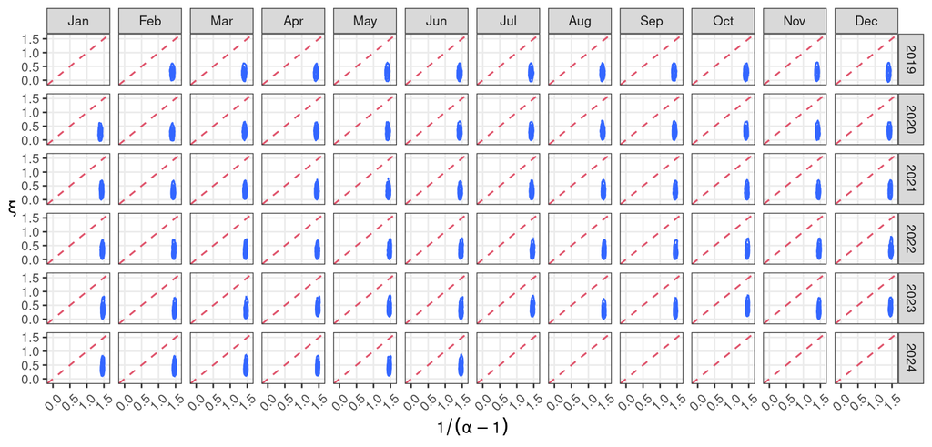

# Summary

- Degrees seemingly follow the power law
  - wholly or partially
- Extreme value mixture distribution
  - power law $(\alpha)$ in the body
  - integer generalised Pareto $(\xi,\ldots)$ in the tail
- Comparing $\xi$ and $1/(\alpha-1)$
  - indicates if power law applies to whole of data
- Application: CRAN dependencies
  - seeming stability over time
- Next steps
  - evolution of the raw data
  - what model (modification) leads to such behaviour
- Slides: https://bit.ly/sunbelt2024

[figure not shown]

- R package: https://cran.r-project.org/package=crandep
- Paper: https://doi.org/10.1111/stan.12355

# Bibliography

Artico, I., I. Smolyarenko, V. Vinciotti, and E. C. Wit. 2020. “How Rare Are Power-Law Networks Really?” *Proceedings of the Royal Society A: Mathematical, Physical and Engineering Sciences* 476 (2241): 20190742. https://doi.org/10.1098/rspa.2019.0742.

Ayed, Fadhel, Juho Lee, and François Caron. 2019. “Beyond the Chinese Restaurant and Pitman-Yor Processes: Statistical Models with Double Power-Law Behavior.” *ArXiv E-Print*. http://arxiv.org/abs/1902.04714.

Broido, A. D., and A. Clauset. 2019. “Scale-Free Networks Are Rare.” *Nature Communications* 10 (1017). https://doi.org/10.1038/s41467-019-08746-5.

Clauset, A., C. R. Shalizi, and M. E. J. Newman. 2009. “Power-Law Distributions in Empirical Data.” *SIAM Review* 51 (4): 661–703. https://doi.org/10.1137/070710111.

Jung, Hohyun, and Frederick Kin Hing Phoa. 2021. “A Mixture Model of Truncated Zeta Distributions with Applications to Scientific Collaboration Networks.” *Entropy* 23 (5). https://doi.org/10.3390/e23050502.

Valero, Jordi, Marta Pérez-Casany, and Ariel Duarte-López. 2022. “The Zipf-Polylog Distribution: Modeling Human Interactions Through Social Networks.” *Physica A* 603. https://doi.org/10.1016/j.physa.2022.127680.

Voitalov, Ivan, Pim van der Hoorn, Remco van der Hofstad, and Dmitri Krioukov. 2019. “Scale-Free Networks Well Done.” *Phys. Rev. Res.* 1 (3): 033034. https://doi.org/10.1103/PhysRevResearch.1.033034.